# Project Title: Natural Gas Price Forecasting and Extrapolation

## Project Description:

In this project, I aim to enhance the granularity of natural gas price data by extrapolating it based on historical trends and seasonal variations related to different months of the year. The goal is to provide accurate price estimates for any given date, including a one-year future projection.

To achieve this, I will follow the following steps:

Data Acquisition: We will download monthly natural gas price data spanning from October 31, 2020, to September 30, 2024. Each data point represents the purchase price of natural gas at the end of a month.

Data Analysis: We will analyze the historical price data to estimate the purchase price of gas at any specific date in the past. This analysis will involve identifying patterns, trends, and factors influencing price fluctuations.

Extrapolation: Using the insights gained from the data analysis, we will extrapolate the natural gas prices for one year into the future. This will provide an indicative price for longer-term storage contracts.

Price Estimation: We will develop a Python code that takes a date as input and returns a price estimate based on our analysis and extrapolation model.

Visualization: We will create visualizations to better understand the data, identify seasonal trends, and factors affecting price variations. This will aid in the accuracy of our price estimates.

```python
from google.colab import drive
drive.mount('/content/drive')
!cd /content/drive/MyDrive/QuantAnalyis/
```

```python
!mv /content/drive/MyDrive/Colab\ Notebooks/PredictPrice_JP.ipynb /content/drive/MyDrive/QuantAnalyis/
```

```python
!pip install statsmodels
```

```python
from matplotlib import dates
import matplotlib.pyplot as plt
import numpy as np
import pandas as pd
import seaborn as sb
```

```python
!python --version
```

```
Python 3.10.12
```

```python
df = pd.read_csv("/content/drive/MyDrive/QuantAnalyis/InputDir/Nat_Gas.csv")
df
df['Dates'] = pd.to_datetime(df['Dates'])
df.set_index('Dates', inplace=True)
```

```python
df.info()
```

```
<class 'pandas.core.frame.DataFrame'>
DatetimeIndex: 48 entries, 2020-10-31 to 2024-09-30
Data columns (total 1 columns):
 #   Column  Non-Null Count  Dtype
---  ------  --------------  -----
 0   Prices  48 non-null     float64
dtypes: float64(1)
memory usage: 768.0 bytes
```

[output not shown]

Values

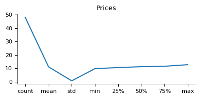

Distributions

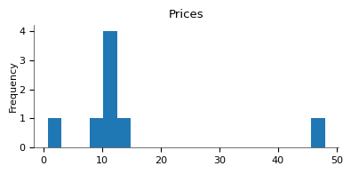

```python
df.describe()
```

# Visualization of Time Series

```python
# To check stationary series or not
from statsmodels.tsa.stattools import adfuller
def adf_test(timeseries):
    print ('Results of Dickey-Fuller Test:')
    dftest = adfuller(timeseries, autolag='AIC')
    dfoutput = pd.Series(dftest[0:4], index=['Test Statistic','p-value','#Lags Used','Number of Observations Used'])
    for key,value in dftest[4].items():
        dfoutput['Critical Value (%s)'%key] = value
    print (dfoutput)
adf_test(df['Prices'])
```

```
Results of Dickey-Fuller Test:
Test Statistic                  0.218077
p-value                         0.973257
#Lags Used                     10.000000
Number of Observations Used    37.000000
Critical Value (1%)            -3.620918
Critical Value (5%)            -2.943539
Critical Value (10%)           -2.610400
dtype: float64
```

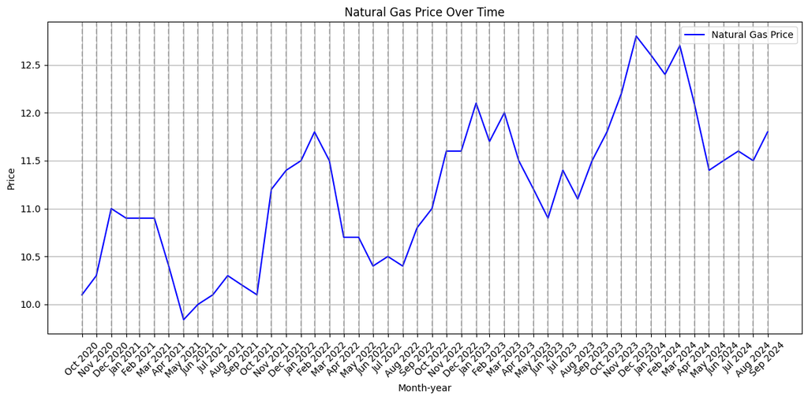

```python
# Convert the date column to datetime format

# Set the Date column as the index
#df.set_index('Dates', inplace=True)
# Create a new column for MonthYear
df['MonthYear'] = df.index.strftime('%b %Y')


# Plot the natural gas prices over time
plt.figure(figsize=(12, 6))
plt.plot(df.index, df['Prices'], label='Natural Gas Price', color='blue')
plt.title('Natural Gas Price Over Time')
plt.xlabel('Month-year')
plt.ylabel('Price')
plt.grid(True)

# Get unique MonthYear values for x-axis labels
month_year_ticks = df['MonthYear'].unique()

# Set x-axis ticks at the positions corresponding to MonthYear values
plt.xticks(df.index, df['MonthYear'], rotation=45)

# Add labels for MonthYear to identify seasonal trends
for month_year in month_year_ticks:
    plt.axvline(x=df[df['MonthYear'] == month_year].index[0], color='gray', linestyle='--', alpha=0.5)

plt.legend()
plt.tight_layout()
```

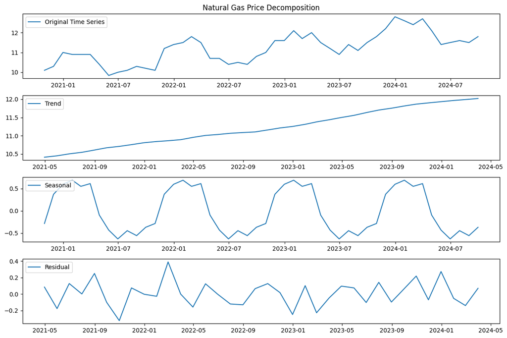

```python
from statsmodels.tsa.seasonal import seasonal_decompose

# Decompose the time series into trend, seasonality, and residual components
decomposition = seasonal_decompose(df['Prices'], model='additive', period=12)  # Adjust the period as needed
trend_component = decomposition.trend.dropna()
seasonal_component = decomposition.seasonal

# Plot the original time series
plt.figure(figsize=(12, 8))
plt.subplot(411)
plt.plot(df.index, df['Prices'], label='Original Time Series')
plt.legend(loc='upper left')
plt.title('Natural Gas Price Decomposition')

# Plot the trend component
plt.subplot(412)
plt.plot(df.index, decomposition.trend, label='Trend')
plt.legend(loc='upper left')

# Plot the seasonal component
plt.subplot(413)
plt.plot(df.index, decomposition.seasonal, label='Seasonal')
plt.legend(loc='upper left')

# Plot the residual component
plt.subplot(414)
plt.plot(df.index, decomposition.resid, label='Residual')
plt.legend(loc='upper left')

plt.tight_layout()

# Show the plot
plt.show()
```

The above decomposition definately points outs the upward trend and recurring monthly/yearly patterns in the data. The residual represent the remaining variability in data called noise and refer to unusual events or anomalies in the data

Extracting and removing time series seasonal component

```python
# Remove the seasonal component from the original data
deseasonalized_data = df['Prices'] - seasonal_component
```

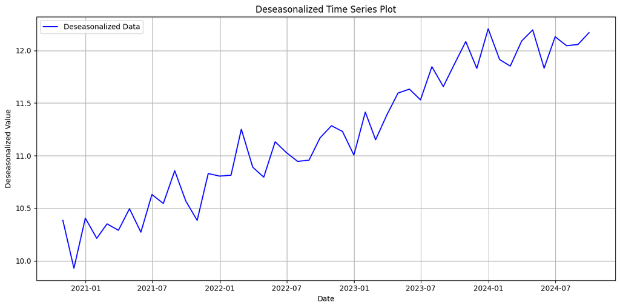

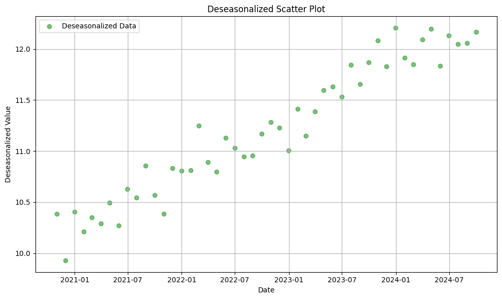

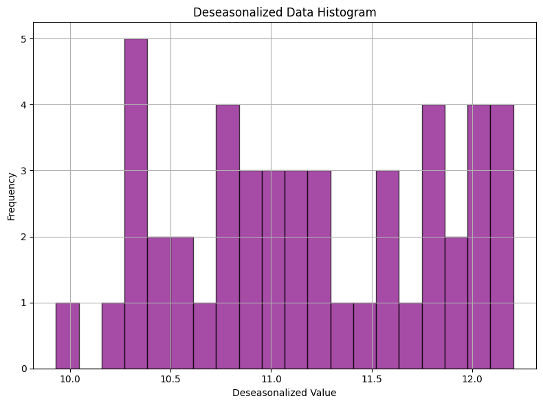

```python
import matplotlib.pyplot as plt

# Create a time series plot to visualize the trend
plt.figure(figsize=(12, 6))
plt.plot(deseasonalized_data.index, deseasonalized_data, label='Deseasonalized Data', color='blue')
plt.title('Deseasonalized Time Series Plot')
plt.xlabel('Date')
plt.ylabel('Deseasonalized Value')
plt.grid(True)
plt.legend()
plt.tight_layout()

# Create a scatter plot to visualize relationships or patterns
plt.figure(figsize=(10, 6))
plt.scatter(deseasonalized_data.index, deseasonalized_data, label='Deseasonalized Data', color='green', alpha=0.5)
plt.title('Deseasonalized Scatter Plot')
plt.xlabel('Date')
plt.ylabel('Deseasonalized Value')
plt.grid(True)
plt.legend()
plt.tight_layout()

# Create a histogram to visualize the distribution of the data
plt.figure(figsize=(8, 6))
plt.hist(deseasonalized_data, bins=20, edgecolor='black', alpha=0.7, color='purple')
plt.title('Deseasonalized Data Histogram')
plt.xlabel('Deseasonalized Value')
plt.ylabel('Frequency')
plt.grid(True)
plt.tight_layout()

# Show all the plots
plt.show()
```

# Analysis part 1 : ARIMA(SARIMA)

# ARIMA : Auto Regression Integrated Moving averages

For ARIMA p,q,d determination is very crucial.

p,q are related to seasonality where as d is related to trend

d = 1 Integrated order (for differencing)

p = 1 AutoRegressive order

q = 1 Moving Average order

Differencing(d): by differencing the series and using a lagged version of the series. This is done by subtracting the previous observation from the current observation. To go further deeper if it doesn't work is to take the second difference, third, and so forth.

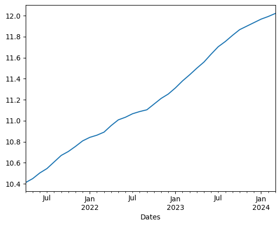

```python
trend_component.plot()
```

```python
trdiff = trend_component.diff()
```

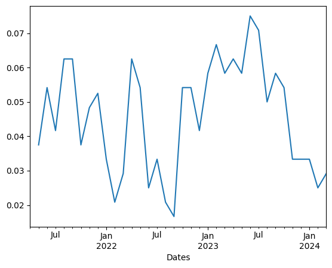

```python
trdiff.plot()
```

[figure not shown]

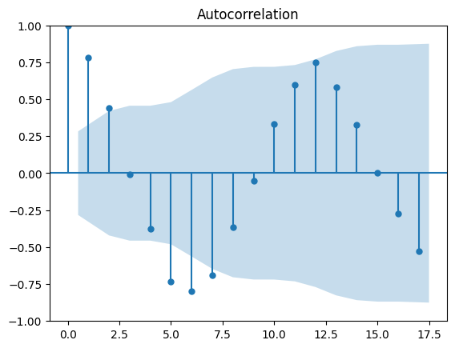

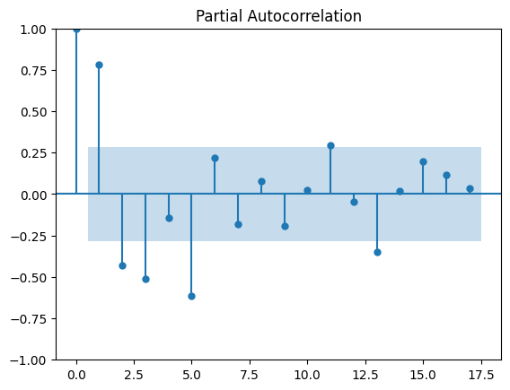

```python
from statsmodels.graphics.tsaplots import plot_acf, plot_pacf
plot_acf(seasonal_component)
plot_pacf(seasonal_component)
```

```python
df
```

```python
df.drop('MonthYear', axis=1, inplace=True)
```

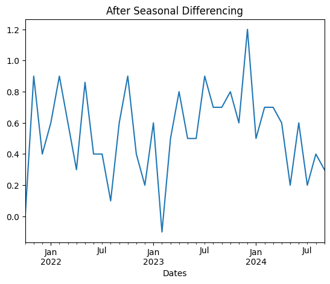

```python
df['diff'] = df['Prices'].diff(12)
df['diff'].dropna().plot(title='After Seasonal Differencing')
plt.show()
```

```python
result = adfuller(df['diff'].dropna())
print('ADF Statistic:', result[0])
print('p-value:', result[1])
```

```
ADF Statistic: -6.338337757875165
p-value: 2.7945314748502356e-08
```

as p value is less than 0.05 so the ttime series is stationay (constant mean and variance)

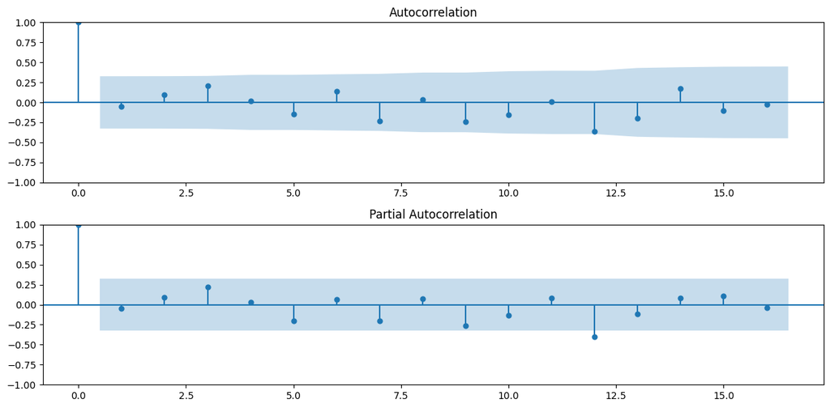

```python
plt.figure(figsize=(12, 6))

plt.subplot(211)
plot_acf(df['diff'].dropna(), ax=plt.gca())

plt.subplot(212)
plot_pacf(df['diff'].dropna(), ax=plt.gca())

plt.tight_layout()
plt.show()
```

```
Plot both the ACF and PACF for your differenced series.

ACF:
    If the ACF plot shows a gradual decline, it often suggests that there's a positive auto-regressive term, hinting at a specific AR(p) value.
    If the ACF plot shows a sharp cutoff while the PACF plot shows a gradual or more prolonged decline, it's indicative of the MA(qq) order of the model.

PACF:
    If the PACF shows a sharp cutoff while the ACF shows a gradual decline, it suggests a positive auto-regressive term, hinting at a specific AR(pp) value.
    If the PACF plot shows a spike at lag kk and zero after lag kk, then kk may be the order of the AR term.

Rules of Thumb:
    If the series has positive autocorrelation at lag 1, then consider adding an AR term.
    If there's a significant spike at lag k in the PACF, consider using kk as the AR(p) order.
    If the ACF shows exponential decay and the PACF shows a spike at lag kk, then consider using k as the MA(qq) order.
```

As we didn't find conclusive values throughh visulaization we can use auto grid search

since seasonal series is stationary D=1 we applied one time differencing and s =12 i.e. seasonal order

```python
df
```

```python
df.drop(['diff','MonthYear'], axis = 1, inplace = True)
```

```python
df
```

```python
import pandas as pd
import numpy as np
import itertools
import warnings
from statsmodels.tsa.statespace.sarimax import SARIMAX
from sklearn.metrics import mean_squared_error

# Assuming df is already loaded
# df = pd.read_csv('your_data_file.csv')
# df['date'] = pd.to_datetime(df['date'])
# df.set_index('date', inplace=True)

# Function to fit and forecast using SARIMA
def sarima_forecast(train, order, seasonal_order, steps=12):
    model = SARIMAX(train, order=order, seasonal_order=seasonal_order, enforce_stationarity=False, enforce_invertibility=False)
    results = model.fit(disp=0)
    forecast = results.get_forecast(steps=steps).predicted_mean
    return forecast

# Grid search for SARIMA parameters
p = d = q = range(0, 3)
pdq = list(itertools.product(p, d, q))
seasonal_pdq = [(x[0], x[1], x[2], 12) for x in pdq]

warnings.filterwarnings("ignore")

best_aic = np.inf
best_order = None
best_seasonal_order = None

for order in pdq:
    for seasonal_order in seasonal_pdq:
        try:
            model = SARIMAX(df['Prices'], order=order, seasonal_order=seasonal_order, enforce_stationarity=False, enforce_invertibility=False)
            results = model.fit(disp=0)
            if results.aic < best_aic:
                best_aic = results.aic
                best_order = order
                best_seasonal_order = seasonal_order
        except:
            continue

print(f"Best SARIMA parameters: {best_order}x{best_seasonal_order} with AIC={best_aic}")

# Splitting data into train and test sets
train = df['Prices'][:-12]
test = df['Prices'][-12:]

# Forecast using the best parameters
forecast = sarima_forecast(train, best_order, best_seasonal_order)

# Calculate RMSE
mse = mean_squared_error(test, forecast)
rmse = np.sqrt(mse)
print(f"RMSE: {rmse}")

# Forecast the next 12 months after the entire dataset
future_forecast = sarima_forecast(df['Prices'], best_order, best_seasonal_order)
print(f"Future 12 months forecast: {future_forecast}")
```

```
Best SARIMA parameters: (1, 0, 2)x(2, 1, 2, 12) with AIC=-9.685922724575448
RMSE: 0.3588896203717877
Future 12 months forecast: 2024-10-31    11.557660
2024-11-30    12.448117
2024-12-31    13.128628
2025-01-31    12.653259
2025-02-28    12.889722
2025-03-31    12.871809
2025-04-30    12.027057
2025-05-31    11.529683
2025-06-30    11.586657
2025-07-31    11.425082
2025-08-31    11.349551
2025-09-30    11.756646
Freq: M, Name: predicted_mean, dtype: float64
```

```python
#Extending the original series with the forecast
extended_series = df['Prices'].append(pd.Series(future_forecast, index=pd.date_range(df['Prices'].index[-1], periods=13, closed='right',freq='M')))
```

```python
pd.date_range(df['Prices'].index[-1],periods=12, closed='right', freq='M')
```

```
DatetimeIndex(['2024-10-31', '2024-11-30', '2024-12-31', '2025-01-31',
               '2025-02-28', '2025-03-31', '2025-04-30', '2025-05-31',
               '2025-06-30', '2025-07-31', '2025-08-31'],
              dtype='datetime64[ns]', freq='M')
```

```python
extended_series
```

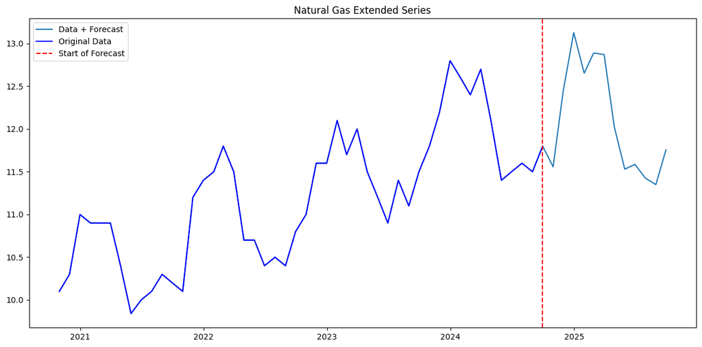

```python
plt.figure(figsize=(15, 7))
plt.plot(extended_series, label='Data + Forecast')
plt.plot(df['Prices'], label='Original Data', color='blue')
plt.axvline(x=df.index[-1], color='red', linestyle='--', label='Start of Forecast')
plt.legend()
plt.title('Natural Gas Extended Series')
plt.show()
```

# Analysis part 2

From the plot - we can see the prices have a natural frequency of around a year, but trend upwards. We can do a linear regression to get the trend, and then fit a sin function to the variation in each year.

```python
df
```

```python
prices = df['Prices'].values
dates = df.index
```

```python
start_date = df.index[0]
end_date = df.index[-1]
months = []
year = start_date.year
month = start_date.month + 1
```

```python
# Create a date range of month-end dates between start_date and end_date
month_end_dates = pd.date_range(start=start_date, end=end_date, freq='M') - pd.offsets.MonthEnd(0)

# Calculate the number of days from start_date to each month-end date
days_from_start = (month_end_dates - start_date).days

print(month_end_dates)
print(days_from_start)
```

```
DatetimeIndex(['2020-10-31', '2020-11-30', '2020-12-31', '2021-01-31',
               '2021-02-28', '2021-03-31', '2021-04-30', '2021-05-31',
               '2021-06-30', '2021-07-31', '2021-08-31', '2021-09-30',
               '2021-10-31', '2021-11-30', '2021-12-31', '2022-01-31',
               '2022-02-28', '2022-03-31', '2022-04-30', '2022-05-31',
               '2022-06-30', '2022-07-31', '2022-08-31', '2022-09-30',
               '2022-10-31', '2022-11-30', '2022-12-31', '2023-01-31',
               '2023-02-28', '2023-03-31', '2023-04-30', '2023-05-31',
               '2023-06-30', '2023-07-31', '2023-08-31', '2023-09-30',
               '2023-10-31', '2023-11-30', '2023-12-31', '2024-01-31',
               '2024-02-29', '2024-03-31', '2024-04-30', '2024-05-31',
               '2024-06-30', '2024-07-31', '2024-08-31', '2024-09-30'],
              dtype='datetime64[ns]', freq=None)
Int64Index([   0,   30,   61,   92,  120,  151,  181,  212,  242,  273,  304,
             334,  365,  395,  426,  457,  485,  516,  546,  577,  607,  638,
             669,  699,  730,  760,  791,  822,  850,  881,  911,  942,  972,
            1003, 1034, 1064, 1095, 1125, 1156, 1187, 1216, 1247, 1277, 1308,
            1338, 1369, 1400, 1430],
           dtype='int64')
```

Simple regression for the trend will fit to a model y = Ax + B.

The estimator for the slope is given by \hat{A} = \frac{\sum (x_i - \bar{x})(y_i - \bar{y})}{\sum (x_i - \bar{x})^2},

The intercept by \hat{B} = \bar{y} - hat{A} * \xbar

```python
def simple_regression(x, y):
    xbar = np.mean(x)
    ybar = np.mean(y)
    slope = np.sum((x - xbar) * (y - ybar))/ np.sum((x - xbar)**2)
    intercept = ybar - slope*xbar
    return slope, intercept
```

```python
prices = np.array(df['Prices'])
time = np.array(days_from_start)
slope, intercept = simple_regression(time, prices)
```

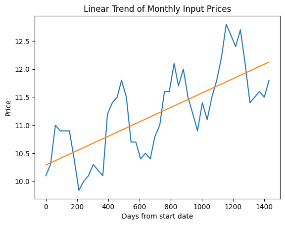

```
0.001282373598760221 10.29104112595228
```

```python
# Plot linear trend
plt.plot(time, prices)
plt.plot(time, time * slope + intercept)
plt.xlabel('Days from start date')
plt.ylabel('Price')
plt.title('Linear Trend of Monthly Input Prices')
plt.show()
print(slope, intercept)
```

From this plot we see the linear trend has been captured. Now to fit the intra-year variation. Given that natural gas is used more in winter, and less in summer, we can guess the frequency of the price movements to be about a year, or 12 months. Therefore we have a model y = Asin( kt + z ) with a known frequency.Rewriting y = Acos(z)sin(kt) + Asin(z)cos(kt), we can use bilinear regression, with no intercept, to solve for u = Acos(z), w = Asin(z)

```python
sin_prices = prices - (time * slope + intercept)
sin_time = np.sin(time * 2 * np.pi / (365))
cos_time = np.cos(time * 2 * np.pi / (365))

def bilinear_regression(y, x1, x2):
    # Bilinear regression without an intercept amounts to projection onto the x-vectors
    slope1 = np.sum(y * x1) / np.sum(x1 ** 2)
    slope2 = np.sum(y * x2) / np.sum(x2 ** 2)
    return(slope1, slope2)

slope1, slope2 = bilinear_regression(sin_prices, sin_time, cos_time)
```

```python
amplitude = np.sqrt(slope1 ** 2 + slope2 ** 2)
shift = np.arctan2(slope2, slope1)
```

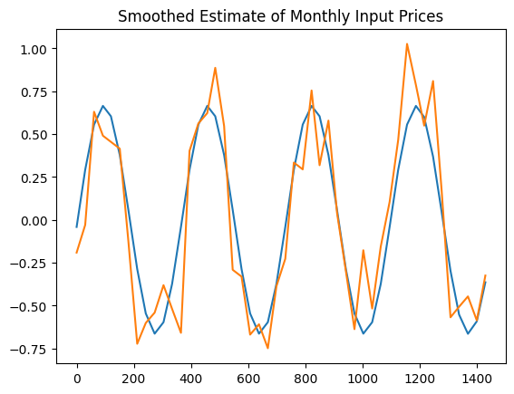

```python
# Plot smoothed estimate of full dataset
plt.plot(time, amplitude * np.sin(time * 2 * np.pi / 365 + shift))
plt.plot(time, sin_prices)
plt.title('Smoothed Estimate of Monthly Input Prices')
```

```python
## Define the interpolation/extrapolation function
def interpolate(date):
    days = (date - start_date).days
    indices = days_from_start.get_indexer([days])  # Use get_indexer to find the index
    if indices[0] >= 0:
        # Exact match found in the data
        return prices[indices[0]]
    else:
    #if days in days_from_start:
    #    # Exact match found in the data
    #    return prices[days_from_start.index(days)]
    #else:
        # Interpolate/extrapolate using the sin/cos model
        return amplitude * np.sin(days * 2 * np.pi / 365 + shift) + days * slope + intercept
```

```python
np.array(days_from_start)
```

```
array([   0,   30,   61,   92,  120,  151,  181,  212,  242,  273,  304,
        334,  365,  395,  426,  457,  485,  516,  546,  577,  607,  638,
        669,  699,  730,  760,  791,  822,  850,  881,  911,  942,  972,
       1003, 1034, 1064, 1095, 1125, 1156, 1187, 1216, 1247, 1277, 1308,
       1338, 1369, 1400, 1430])
```

```python
np.array(prices)
```

```
array([10.1 , 10.3 , 11.  , 10.9 , 10.9 , 10.9 , 10.4 ,  9.84, 10.  ,
       10.1 , 10.3 , 10.2 , 10.1 , 11.2 , 11.4 , 11.5 , 11.8 , 11.5 ,
       10.7 , 10.7 , 10.4 , 10.5 , 10.4 , 10.8 , 11.  , 11.6 , 11.6 ,
       12.1 , 11.7 , 12.  , 11.5 , 11.2 , 10.9 , 11.4 , 11.1 , 11.5 ,
       11.8 , 12.2 , 12.8 , 12.6 , 12.4 , 12.7 , 12.1 , 11.4 , 11.5 ,
       11.6 , 11.5 , 11.8 ])
```

```python
continuous_dates = pd.date_range(start=start_date, end=end_date, freq='D')
continuous_dates
```

```
DatetimeIndex(['2020-10-31', '2020-11-01', '2020-11-02', '2020-11-03',
               '2020-11-04', '2020-11-05', '2020-11-06', '2020-11-07',
               '2020-11-08', '2020-11-09',
               ...
               '2024-09-21', '2024-09-22', '2024-09-23', '2024-09-24',
               '2024-09-25', '2024-09-26', '2024-09-27', '2024-09-28',
               '2024-09-29', '2024-09-30'],
              dtype='datetime64[ns]', length=1431, freq='D')
```

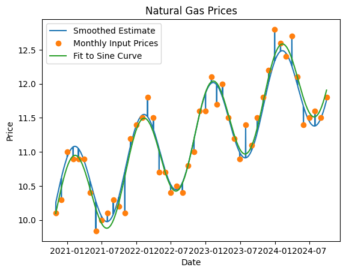

```python
# Create a range of continuous dates from start date to end date
continuous_dates = pd.date_range(start=start_date, end=end_date, freq='D')

# Plot the smoothed estimate of the full dataset using interpolation
#smoothh_data = [interpolate(date) for date in continuous_dates]
plt.plot(continuous_dates, [interpolate(date) for date in continuous_dates], label='Smoothed Estimate')

# Fit the monthly input prices to the sine curve
x = np.array(days_from_start)
y = np.array(prices)
fit_amplitude = np.sqrt(slope1 ** 2 + slope2 ** 2)
fit_shift = np.arctan2(slope2, slope1)
fit_slope, fit_intercept = simple_regression(x, y - fit_amplitude * np.sin(x * 2 * np.pi / 365 + fit_shift))
plt.plot(dates, y, 'o', label='Monthly Input Prices')
plt.plot(continuous_dates, fit_amplitude * np.sin((continuous_dates - pd.Timestamp(start_date)).days * 2 * np.pi / 365 + fit_shift) + (continuous_dates - pd.Timestamp(start_date)).days * fit_slope + fit_intercept, label='Fit to Sine Curve')

plt.xlabel('Date')
plt.ylabel('Price')
plt.title('Natural Gas Prices')
plt.legend()
plt.show()
```

# End of Part 1

# 2. You need to create a prototype pricing model

that can go through further validation and testing before being put into production. Eventually, this model may be the basis for fully automated quoting to clients, but for now, the desk will use it with manual oversight to explore options with the client.

You should write a function that is able to use the data you created previously to price the contract. The client may want to choose multiple dates to inject and withdraw a set amount of gas, so your approach should generalize the explanation from before. Consider all the cash flows involved in the product.

The input parameters that should be taken into account for pricing are:

```
Injection dates.
Withdrawal dates.
The prices at which the commodity can be purchased/sold on those dates.
The rate at which the gas can be injected/withdrawn.
The maximum volume that can be stored.
Storage costs.
```

Write a function that takes these inputs and gives back the value of the contract. You can assume there is no transport delay and that interest rates are zero. Market holidays, weekends, and bank holidays need not be accounted for. Test your code by selecting a few sample inputs.

```python
daily_prices = df['Prices'].resample('D').interpolate(method='linear')
```

```python
daily_prices
```

```
Dates
2020-10-31    10.100000
2020-11-01    10.106667
2020-11-02    10.113333
2020-11-03    10.120000
2020-11-04    10.126667
                ...
2024-09-26    11.760000
2024-09-27    11.770000
2024-09-28    11.780000
2024-09-29    11.790000
2024-09-30    11.800000
Freq: D, Name: Prices, Length: 1431, dtype: float64
```

```python
def price_gas_contract(injection_dates, withdrawal_dates, prices,
                       injection_rate, withdrawal_rate, max_volume, storage_cost):
    """
    Parameters:
    - injection_dates :  Dates when gas will be injected.
    - withdrawal_dates :  Dates when gas will be withdrawn.
    - prices : pd.Series: Gas prices at different dates. Should cover all injection and withdrawal dates.
    - injection_rate : float: Rate at which gas can be injected.
    - withdrawal_rate : float: Rate at which gas can be withdrawn.
    - max_volume : float: Maximum volume of gas that can be stored.
    - storage_cost : float: Cost per unit of gas to store it.

    Returns:
    - float: The net value of the contract based on the inputs.
    """

    # As our data is monthhly ffirst would be good to convert to  daily using interpolation
    df_daily = df['Prices'].resample('D').interpolate(method='linear')


    # Initializations
    storage_level = 0  # Level of gas in storage
    contract_value = 0  # Net value of the contract

    # Injection phase
    for date in injection_dates:
        # Check if the date is in prices index
        if date not in df_daily.index:
            raise ValueError(f"No price available for date: {date}")

        # Calculate the cost to inject gas and update the storage level
        injection_cost = df_daily.loc[date] * injection_rate + storage_cost * injection_rate
        contract_value -= injection_cost
        storage_level += injection_rate

        # Check if storage level exceeds max volume
        if storage_level > max_volume:
            raise ValueError("Injected volume exceeds maximum storage capacity.")

    # Withdrawal phase
    for date in withdrawal_dates:
        # Check if the date is in prices index
        if date not in df_daily.index:
            raise ValueError(f"No price available for date: {date}")

        # Calculate the revenue from withdrawing gas and update the storage level
        withdrawal_revenue = df_daily.loc[date] * withdrawal_rate
        contract_value += withdrawal_revenue
        storage_level -= withdrawal_rate

        # Check if storage level falls below zero
        if storage_level < 0:
            raise ValueError("Withdrawn volume exceeds available gas in storage.")

    return contract_value
```

```python
injection_rate = 100  # MMBtu/day
withdrawal_rate = 100  # MMBtu/day
max_volume = 9000  # MMBtu
storage_cost = 0.05  # $/MMBtu

injection_dates = pd.to_datetime(['2023-01-15', '2023-02-15', '2023-03-15'])
withdrawal_dates = pd.to_datetime(['2024-01-15', '2024-02-15', '2024-02-15'])
contract_rate = price_gas_contract(injection_dates, withdrawal_dates, df,
                       injection_rate, withdrawal_rate, max_volume, storage_cost)
print(contract_rate)
```

```
197.3518194819644
```